# Analysis, Visualization and Mapping in R

## Aula 7 Objetivos

- Entender shapefiles em R
- Tornando os dados espaciais
- Visualizando mapas
- Mapas Interativas

## Shapefiles em R

- Dois formatos: `sp` e `sf` (simple features)
- `sf` funciona com o tidyverse
  - fluxo de trabalho mais fácil
  - somente um tipo de objeto para polygons/lines/points
- Algumas estatísticas espaciais só funcionam com `sp`
- Podemos converter:
  - `sf <- sp %>% st_as_sf()`
  - `sp <- sf %>% as("Spatial")`

## Shapefiles em R

```r
shapefile <- read_sf("Brazil_s.shp")
```

## Shapefiles em R

- dados espaciais residem numa coluna 'geometry'

[output not shown]

## Shapefiles em R

- Para transformar os nossos dados para um outro projection

```r
shapefile <- shapefile %>% st_transform(4326)
```

```
## Simple feature collection with 5567 features and 6 fields
## geometry type:  MULTIPOLYGON
## dimension:      XY
## bbox:           xmin: -73.98761 ymin: -33.74465 xmax: -28.83732 ymax: 5.271841
## epsg (SRID):    4326
## proj4string:    +proj=longlat +datum=WGS84 +no_defs
```

## Shapefiles em R

- Para transformar os nossos dados para um outro projection

```r
shapefile <- shapefile %>% st_transform("+proj=utm +datum=WGS84 +zone=45")
```

```
## Simple feature collection with 5567 features and 6 fields
## geometry type:  MULTIPOLYGON
## dimension:      XY
## bbox:           xmin: -8004892 ymin: -19995880 xmax: -1635900 ymax: 19995700
## epsg (SRID):    32645
## proj4string:    +proj=utm +zone=45 +datum=WGS84 +units=m +no_defs
```

## Shapefiles em R

- Para manipular um shapefile, podemos usar todas as ações do tidyverse

```r
shapefile %>% mutate(AreatoLength=Shape_Area/Shape_Leng) %>%
  filter(CD_GEOCODM==1700251) %>%
  select(CD_GEOCODM,NM_MUNICIP,AreatoLength)
```

```
## Simple feature collection with 1 feature and 3 fields
## geometry type:  MULTIPOLYGON
## dimension:      XY
## bbox:           xmin: -49.73168 ymin: -9.771946 xmax: -48.86819 ymax: -9.161482
## epsg (SRID):    NA
## proj4string:    +proj=longlat +ellps=GRS80 +no_defs
## # A tibble: 1 x 4
##   CD_GEOCODM NM_MUNICIP  AreatoLength                             geometry
##   <chr>      <chr>              <dbl>                  <MULTIPOLYGON [Â°]>
## 1 1700251    ABREULÂNDIA       0.0447 (((-49.36435 -9.249193, -49.2685 -9~
```

## Shapefiles em R

- Às vezes temos uma lista de coordenadas e precisamos criar um shapefile de pontos nós mesmos
- Por exemplo, com 'georeferencing' de endereços

```r
library(ggmap)
addresses <- c("Prefeitura, Recife, Brazil",
               "Caruara, Pernambuco, Brazil")
df <- geocode(addresses)
```

```r
sf_points <- df %>% st_as_sf(coords = c("lon", "lat"), crs = 4326)
```

```
## Simple feature collection with 2 features and 0 fields
## geometry type:  POINT
## dimension:      XY
## bbox:           xmin: -35.97019 ymin: -8.284964 xmax: -34.87859 ymax: -8.047961
## epsg (SRID):    4326
## proj4string:    +proj=longlat +datum=WGS84 +no_defs
##                      geometry
## 1 POINT (-34.87859 -8.047961)
## 2 POINT (-35.97019 -8.284964)
```

## Tornando os dados espaciais

- Um shapefile `sf` é um data.frame!
- Podemos `join` como normal - com colunas do mesmo nome, tipo, e valores
- Lembre-se que precisamos uma tabela de dados com uma linha por cada spatial feature (polygon/point)

```r
data <- cepespdata(year=2014,
                   position="Governor",
                   regional_aggregation="Municipality",
                   political_aggregation="Candidate",
                   state="PE")

data <- data %>%
  group_by(COD_MUN_IBGE) %>%
  mutate(Vote_Pct=(QTDE_VOTOS/sum(QTDE_VOTOS))*100) %>%
  ungroup() %>%
  filter(NOME_URNA_CANDIDATO=="PAULO CÂMARA")

dim(data)
```

```
## [1] 185  59
```

## Tornando os dados espaciais

```r
shapefile <- shapefile %>%
  separate(CD_GEOCODM,into=c("State","Mun"),sep=2, remove=FALSE) %>%
  filter(State==26) %>%
  mutate(COD_MUN_IBGE=as.numeric(CD_GEOCODM))

dim(shapefile)
```

```
## [1] 185  10
```

## Tornando os dados espaciais

```r
merged <- shapefile %>% left_join(data,by="COD_MUN_IBGE")
```

[output not shown]

## Visualizando mapas

- `sf` é fácil de usar com o `ggplot`
- Mas precisamos instalar a versão de desenvolvimento do `ggplot2`

```r
devtools::install_github("tidyverse/ggplot2")
library(ggplot2)
```

## Visualizando mapas

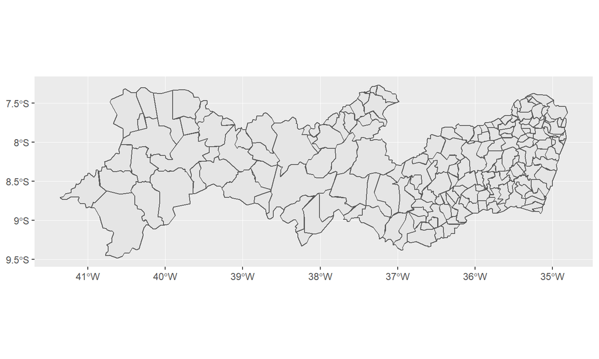

```r
merged %>% ggplot() +
  geom_sf() +
  coord_sf()
```

## Visualizando mapas

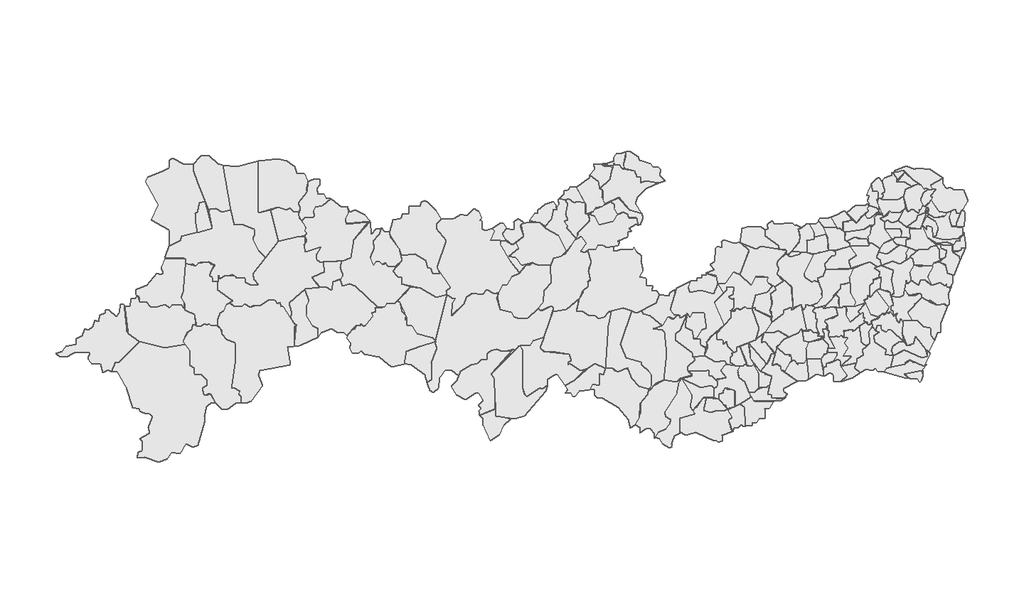

```r
merged %>% ggplot() +
  geom_sf() +
  theme_classic() +
  coord_sf(datum=NA)
```

## Visualizando mapas

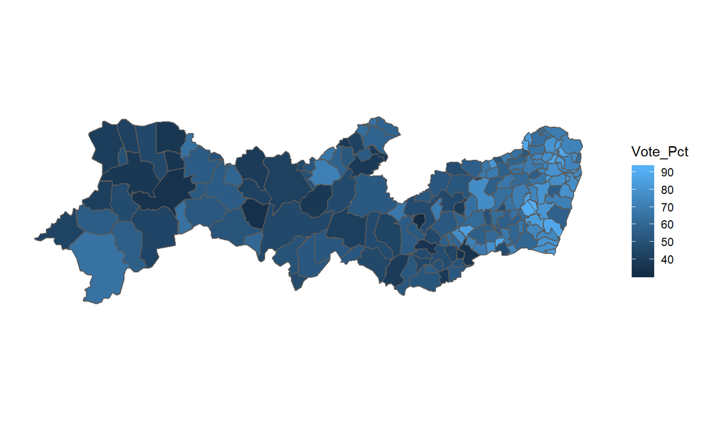

```r
merged %>% ggplot() +
  geom_sf(aes(fill=Vote_Pct)) +
  theme_classic() +
  coord_sf(datum=NA)
```

## Visualizando mapas

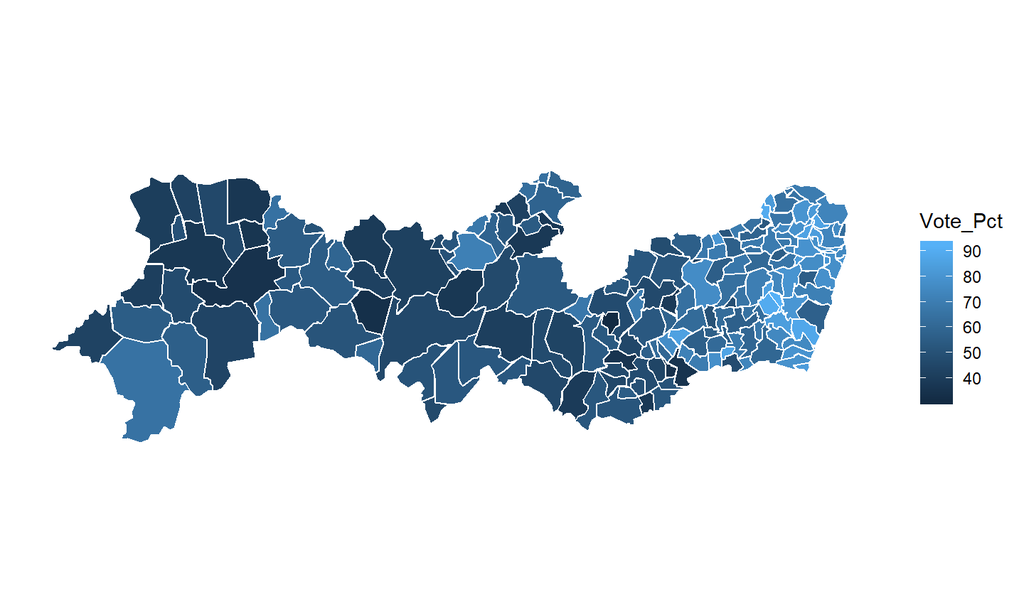

```r
merged %>% ggplot() +
  geom_sf(aes(fill=Vote_Pct), color="white") +
  theme_classic() +
  coord_sf(datum=NA)
```

## Visualizando mapas

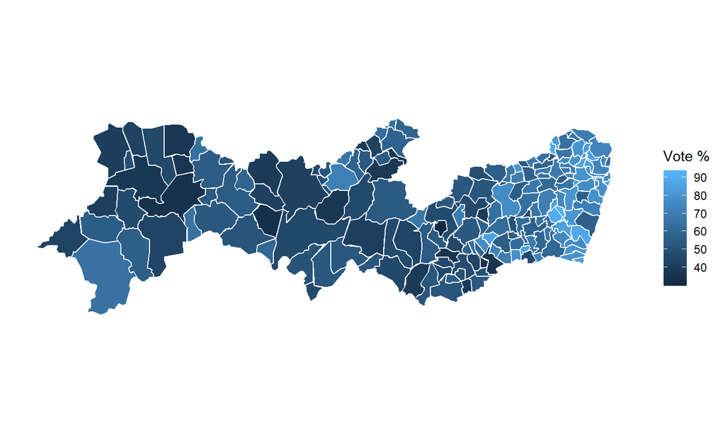

```r
merged %>% rename("Vote %"="Vote_Pct") %>%
  ggplot() +
  geom_sf(aes(fill=`Vote %`), color="white") +
  theme_classic() +
  coord_sf(datum=NA)
```

## Visualizando mapas

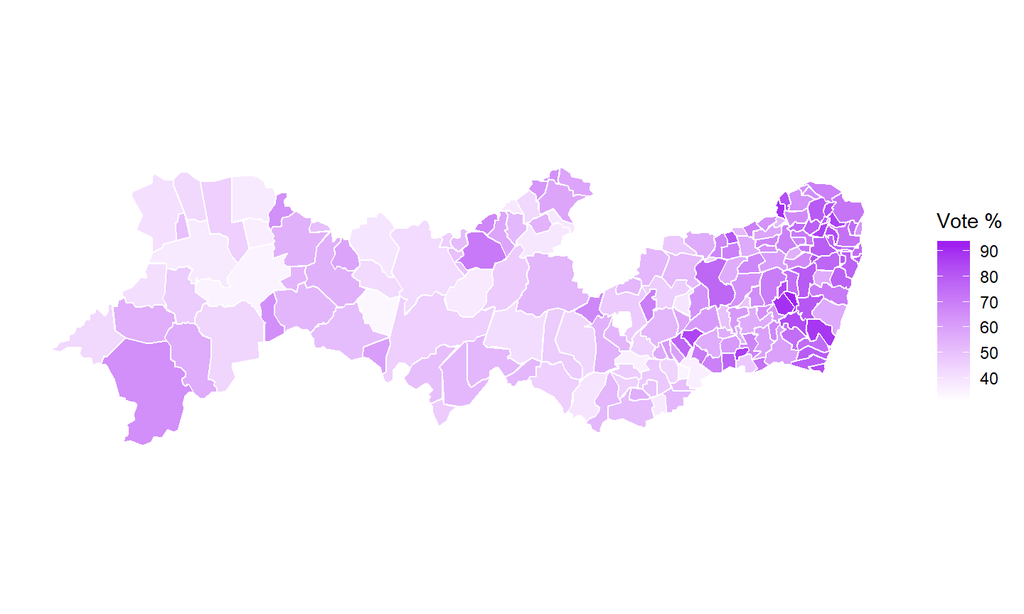

```r
merged %>% rename("Vote %"="Vote_Pct") %>%
  ggplot() +
  geom_sf(aes(fill=`Vote %`), color="white") +
  scale_fill_gradient(low="white",high="purple") +
  theme_classic() +
  coord_sf(datum=NA)
```

## Visualizando mapas

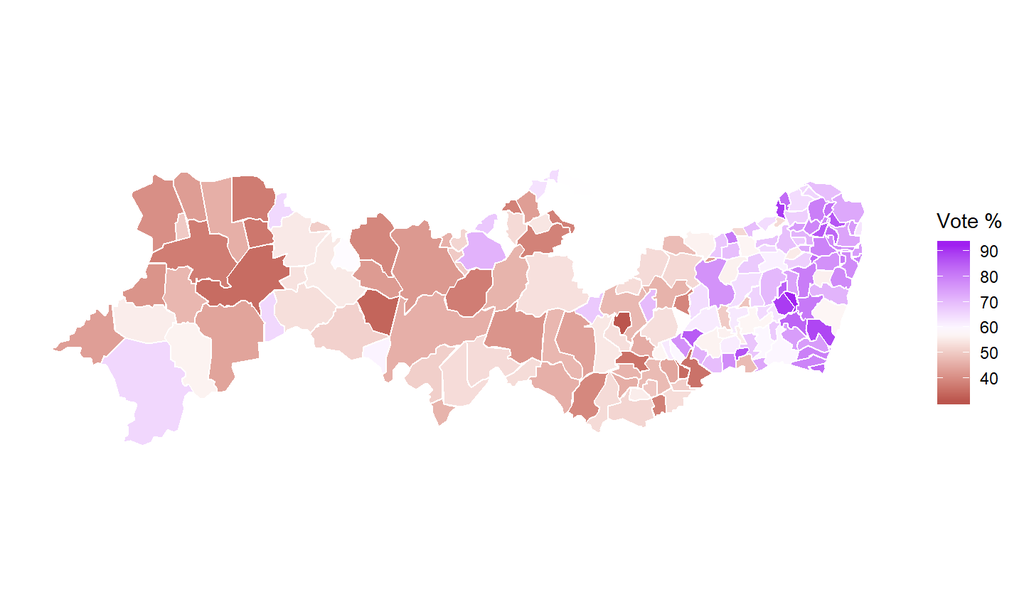

```r
merged %>% rename("Vote %"="Vote_Pct") %>%
  ggplot() +
  geom_sf(aes(fill=`Vote %`), color="white") +
  scale_fill_gradient2(low="brown",mid="white", high="purple",
                       midpoint=median(merged$Vote_Pct,na.rm=T)) +
  theme_classic() +
  coord_sf(datum=NA)
```

## Visualizando mapas

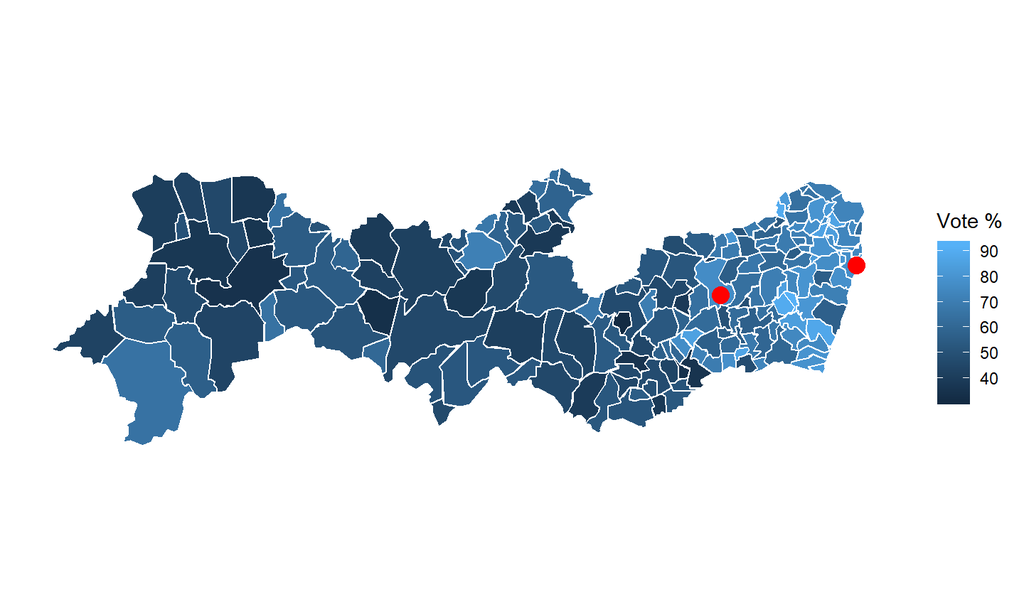

```r
merged %>% rename("Vote %"="Vote_Pct") %>%
  ggplot() +
  geom_sf(aes(fill=`Vote %`), color="white") +
  geom_sf(data=sf_points, col="red",size=4) +
  theme_classic() +
  coord_sf(datum=NA)
```

## Mapas Interativas

```r
library(mapview)
merged %>% mapview()
```

[interactive chart not shown]

## Mapas Interativas

```r
merged %>% mapview(zcol="Vote_Pct", legend=T)
```

[interactive chart not shown]